# ETF Trend Prediction — Modeling Report

MLP signal classifier and LSTM value regressor on ETFs

Author

Milan Kalajdzic

Published

October 8, 2026

## 1. Overview

This report documents the modeling stage of the ETF trend-prediction project. Building on the preprocessing pipeline described in the data preparation report, we train two neural architectures end-to-end on each ETF and benchmark them against a passive **buy-and-hold** baseline:

- **MLP signal model** — a small multilayer perceptron that predicts the next-day trend direction Γ(t) ∈ {+1, −1} as a binary classification target.
- **LSTM value model** — a recurrent network that regresses the next-day return from a 20-day look-back window of features; the sign of the predicted return is the ±1 trading signal.

Both models are evaluated with an **expanding-window walk-forward validator** so every test fold is strictly out-of-sample. Per-fold metrics, daily signals, and equity curves are persisted for every ticker.

| Ticker | Fund | Region / sector |
| --- | --- | --- |
| **EUFN** | iShares MSCI Europe Financials ETF | European financials |
| **FEZ** | SPDR EURO STOXX 50 ETF | Eurozone large-cap |
| **IEUR** | iShares Core MSCI Europe ETF | Broad European market |
| **IVV** | iShares Core S&P 500 ETF | US benchmark |

## 2. The two models

### 2.1 MLP signal model — `MLPSignalModel`

The MLP treats trend prediction as **direct binary classification**: given the scaled indicator vector for day *t*, predict whether Γ(t) = +1 (up) or Γ(t) = −1 (down).

Architecture (src/etf_predictor/models/mlp_signal.py):

```
Input (n_features) → Linear(128) → ReLU → Dropout(0.2)
                  → Linear(64)  → ReLU → Dropout(0.2)
                  → Linear(1)   → Sigmoid
```

Training details:

- **Loss:** `BCEWithLogitsLoss` after mapping {−1, +1} → {0, 1}.
- **Optimiser:** Adam, lr = 1e-3, weight_decay = 1e-5.
- **Batch size:** 64, **epochs:** 30, seeded with `random_state=42`.
- **Inference:** P(Γ = +1) ≥ 0.5 → signal = +1, otherwise −1.

The network is intentionally small so that it can be re-trained from scratch on every fold inside the walk-forward loop without a GPU.

### 2.2 LSTM value model — `LSTMValueModel`

The LSTM is trained as a **regressor on the next-day return**, not as a classifier, so it learns the size of moves as well as their direction, and the trading signal is the sign of the predicted return.

An earlier version regressed the next-day closing *price*, min-max scaled on the training fold. That target breaks out of sample in a rising market: once the price trades above the training range, the network cannot predict a level that high, its prediction falls below the current price, and the signal stays short for as long as the uptrend lasts. Daily returns are stationary, so a scale fitted on the training fold still holds in the test fold.

Architecture (src/etf_predictor/models/lstm_value.py):

```
Input (batch, seq_len=20, n_features) → LSTM(hidden=64, layers=1)
                                       → take last timestep
                                       → Dropout(0.1) → Linear(1)
```

Training details:

- **Target:** next-day simple return of `Close`, standardised with the training fold’s mean and standard deviation (stored so predictions can be mapped back to returns).
- **Loss:** `MSELoss` on the standardised return.
- **Optimiser:** Adam, lr = 1e-3, weight_decay = 1e-5.
- **Batch size:** 64, **epochs:** 20, **sequence length:** 20 trading days, seeded with `random_state=42`.

Signal derivation at inference:

$$\hat{r}_{t+1} = \hat{\mu} + \hat{\sigma}\, f_\theta(x_{t-19}, \dots, x_t),
\quad
\text{signal}_t = \begin{cases} +1 & \hat{r}_{t+1} > 0 \\ -1 & \text{otherwise} \end{cases}$$

where $f_\theta$ is the network output and $\hat{\mu}$, $\hat{\sigma}$ are the training fold’s mean and standard deviation of daily returns.

To predict for the very first row of a test fold, the validator passes the **tail of the training set** (the most recent `sequence_length` rows) as `history`, ensuring that no test-fold prediction is wasted on the warm-up window.

### 2.3 Why two architectures?

- The MLP captures **point-in-time pattern recognition** across the ~250 indicators built in the preprocessing stage.
- The LSTM captures **temporal dependence** across the trailing 20-day window of those same indicators and learns the size of returns rather than only the noisy ±1 label.

Both models emit the same ±1 signal schema, so they plug into the same walk-forward harness and the same equity-curve evaluator.

## 3. Walk-forward validation

The validator (src/etf_predictor/models/walk_forward.py) implements an **expanding-window** scheme:

- **Initial train window:** 750 rows (≈3 years of trading days).
- **Test window:** 120 rows (≈6 months) per fold.
- After each fold the test slice is appended to the training pool and the model is **re-fit from scratch** on the expanded history.

```
fold 1:  train = [0 : 750]            test = [750 : 870]
fold 2:  train = [0 : 870]            test = [870 : 990]
fold k:  train = [0 : 750+(k-1)·120]  test = [750+(k-1)·120 : 750+k·120]
```

For each fold the validator records:

- `signal` ∈ {+1, −1},
- `actual_return` = next-day simple return on unscaled `Close`,
- `strategy_return` = `signal * actual_return`,
- and per-fold metrics: directional accuracy, hit rate, mean return, annualised Sharpe.

This means **every test prediction is strictly out-of-sample**: at the moment the model predicts day *t*, it has only seen days `< t`.

### 3.1 Why expanding (not sliding)?

An expanding window lets each successive model benefit from the full history while still respecting causality. For financial time series this trades slightly older training context for a larger, more diverse training set as the backtest progresses — which we judged to be the right trade-off for these mid-frequency directional signals.

## 4. Equity-curve construction

After all folds finish, the per-day strategy returns are compounded (src/etf_predictor/models/equity.py):

$$\text{Equity}_t = \prod_{s \le t} (1 + r_s^{\text{strategy}})$$

starting at 1.0. The **buy-and-hold** baseline tracks `Close_t / Close_0` on the same test index.

Summary statistics computed for every model and the baseline:

- `total_return`, `annual_return`, `annual_vol`
- `sharpe = annual_return / annual_vol`
- `max_drawdown` (peak-to-trough)
- `hit_rate` (fraction of positive return days)
- `n_days` (number of test days actually traded)

## 5. Results per ETF

```python
import pandas as pd
from pathlib import Path

RESULTS = Path("results")
TICKERS = ["EUFN", "FEZ", "IEUR", "IVV"]

metrics_all = {
    t: pd.read_csv(RESULTS / f"{t}_walkforward_metrics.csv", index_col=0)
    for t in TICKERS
}
```

### 5.0 Results gallery — equity curves across all tickers

A 2×2 view of every walk-forward equity curve. Only the EUFN MLP separates clearly from the passive baseline; on the other three ETFs the buy-and-hold line ends at or above both networks.

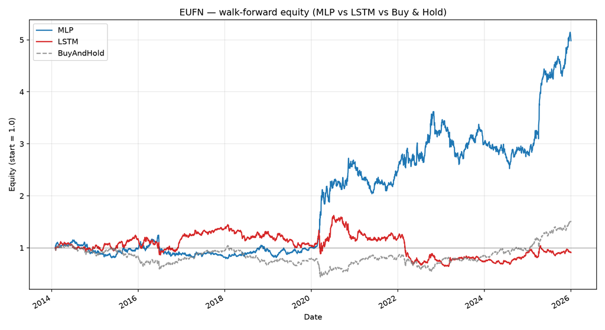

EUFN — equity curves

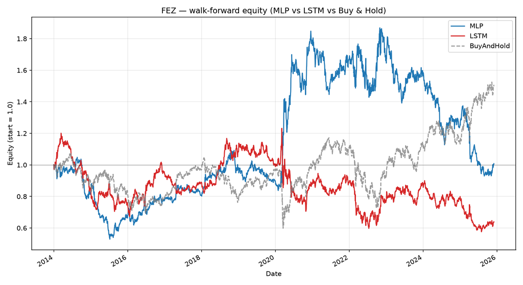

FEZ — equity curves

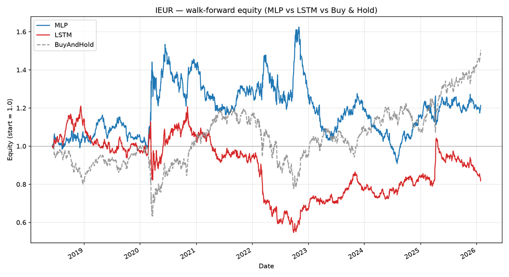

IEUR — equity curves

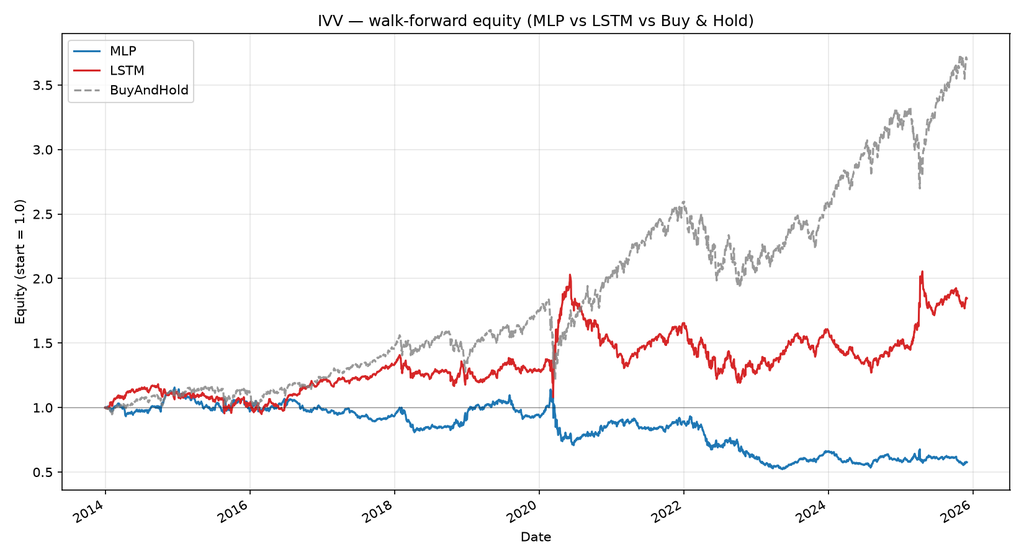

IVV — equity curves

And the matching per-fold directional-accuracy bars:

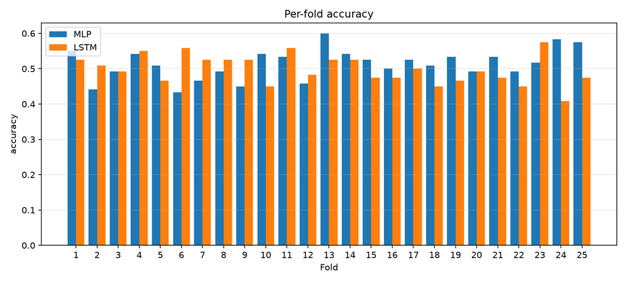

EUFN — per-fold accuracy

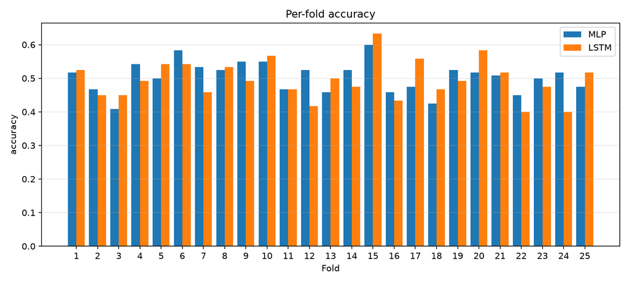

FEZ — per-fold accuracy

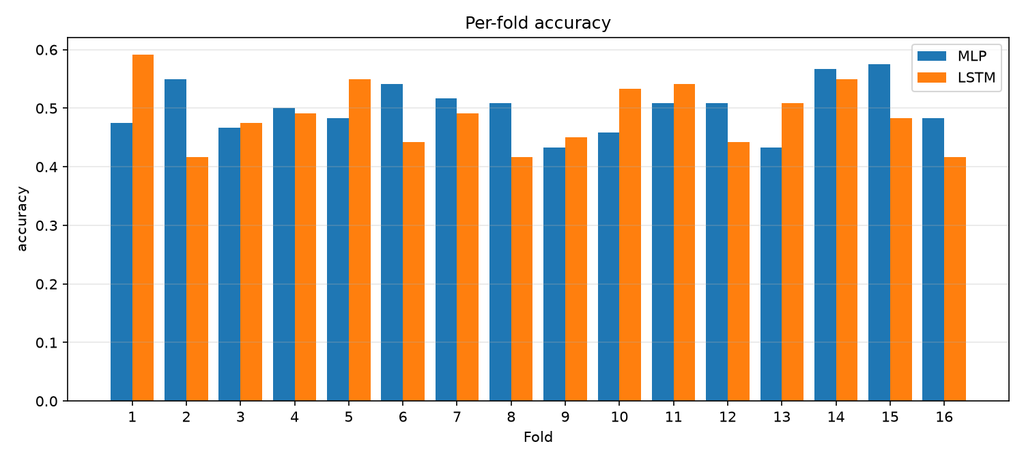

IEUR — per-fold accuracy

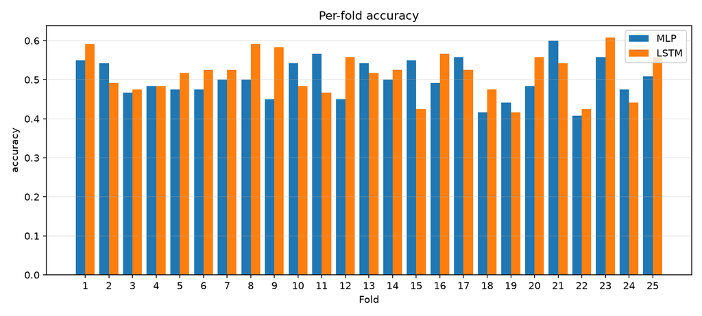

IVV — per-fold accuracy

### 5.1 EUFN — iShares MSCI Europe Financials

```python
metrics_all["EUFN"].round(4)
```

| model | total_return | annual_return | annual_vol | sharpe | max_drawdown | hit_rate | n_days |
| --- | --- | --- | --- | --- | --- | --- | --- |
| MLP | 4.0185 | 0.1451 | 0.2405 | 0.6033 | -0.3631 | 0.5043 | 3000 |
| LSTM | -0.0971 | -0.0085 | 0.2408 | -0.0355 | -0.6042 | 0.4890 | 3000 |
| BuyAndHold | 0.5182 | 0.0357 | 0.2408 | 0.1483 | -0.5914 | 0.5148 | 2999 |

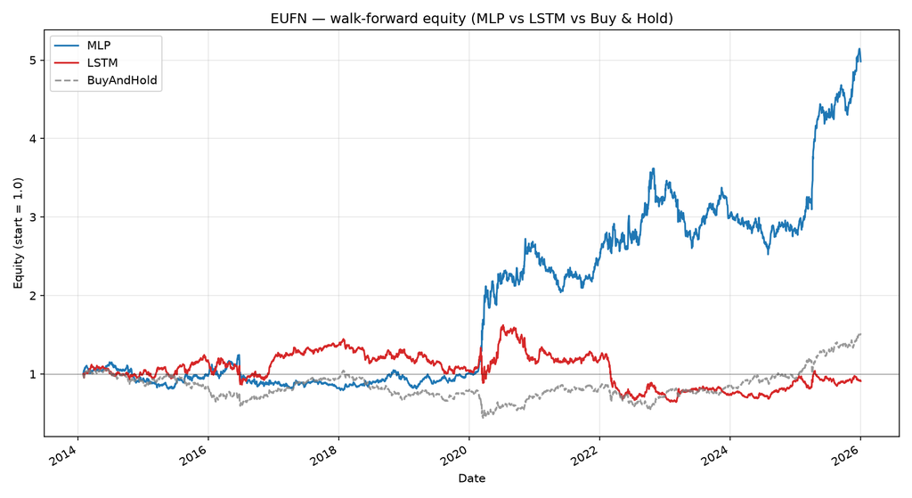

EUFN — walk-forward equity curves (MLP vs LSTM vs Buy & Hold)

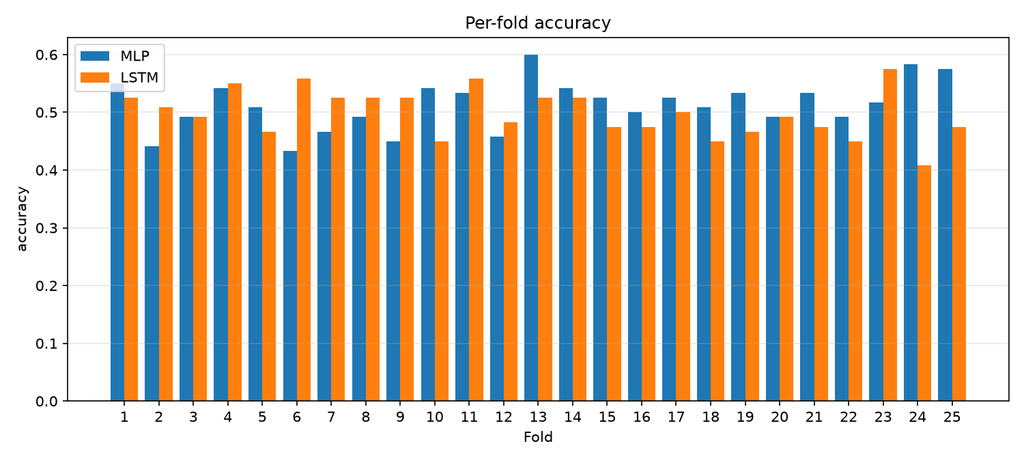

EUFN — per-fold directional accuracy

EUFN is the only ETF where a network clearly beats buy-and-hold. The MLP compounds to about 5× the starting equity (Sharpe 0.60) against 1.5× for buy-and-hold (Sharpe 0.15), with a shallower maximum drawdown (−36% against −59%). The gain is concentrated: 59% of the MLP’s log return comes from ten days, most of them in the March 2020 crash and the April 2025 tariff selloff, and in most other years the strategy is roughly flat. With a hit rate of 50.4%, this looks like being on the right side of a few extreme days rather than a persistent edge. The LSTM ends slightly below where it started (Sharpe −0.04).

### 5.2 FEZ — SPDR EURO STOXX 50

```python
metrics_all["FEZ"].round(4)
```

| model | total_return | annual_return | annual_vol | sharpe | max_drawdown | hit_rate | n_days |
| --- | --- | --- | --- | --- | --- | --- | --- |
| MLP | 0.0147 | 0.0012 | 0.2084 | 0.0059 | -0.5027 | 0.5013 | 3000 |
| LSTM | -0.3562 | -0.0363 | 0.2084 | -0.1742 | -0.5324 | 0.4913 | 3000 |
| BuyAndHold | 0.5078 | 0.0351 | 0.2084 | 0.1685 | -0.4416 | 0.5308 | 2999 |

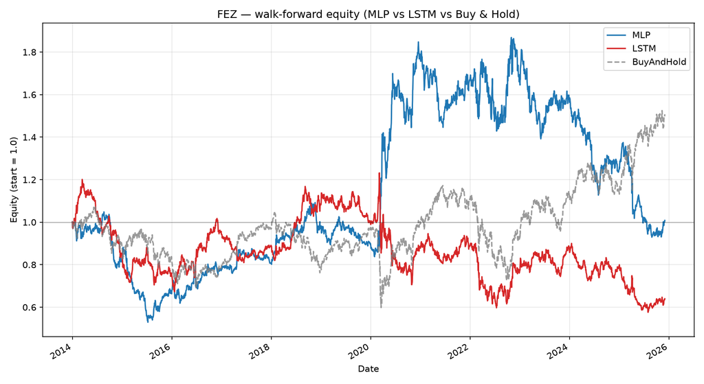

FEZ — walk-forward equity curves (MLP vs LSTM vs Buy & Hold)

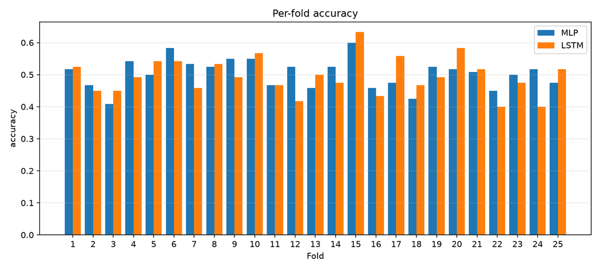

FEZ — per-fold directional accuracy

FEZ is a no-edge case. The MLP finishes almost exactly flat (Sharpe 0.01) and the LSTM loses about a third of its starting equity (Sharpe −0.17), while buy-and-hold returns about 51% (Sharpe 0.17). Per-fold accuracy for both networks scatters around 50%.

### 5.3 IEUR — iShares Core MSCI Europe

```python
metrics_all["IEUR"].round(4)
```

| model | total_return | annual_return | annual_vol | sharpe | max_drawdown | hit_rate | n_days |
| --- | --- | --- | --- | --- | --- | --- | --- |
| MLP | 0.1999 | 0.0242 | 0.1971 | 0.1228 | -0.4406 | 0.4953 | 1920 |
| LSTM | -0.1727 | -0.0246 | 0.1971 | -0.1246 | -0.5479 | 0.4823 | 1920 |
| BuyAndHold | 0.5046 | 0.0551 | 0.1971 | 0.2796 | -0.3726 | 0.5336 | 1919 |

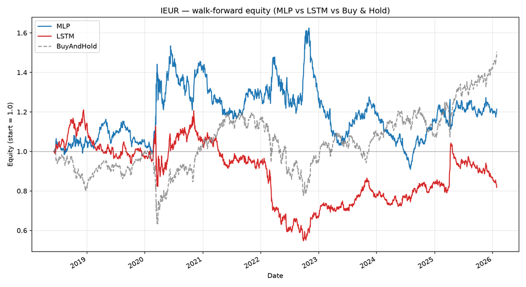

IEUR — walk-forward equity curves (MLP vs LSTM vs Buy & Hold)

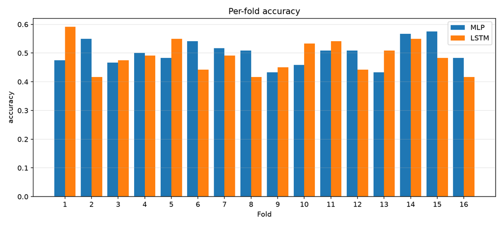

IEUR — per-fold directional accuracy

IEUR has the shortest history. Its data only begins in mid-2014, so 16 folds are available against 25 for the other tickers and the first model trains on less data. Both networks trail buy-and-hold on Sharpe (MLP 0.12, LSTM −0.12, buy-and-hold 0.28).

### 5.4 IVV — iShares Core S&P 500 (US benchmark)

```python
metrics_all["IVV"].round(4)
```

| model | total_return | annual_return | annual_vol | sharpe | max_drawdown | hit_rate | n_days |
| --- | --- | --- | --- | --- | --- | --- | --- |
| MLP | -0.4257 | -0.0455 | 0.1755 | -0.2593 | -0.5479 | 0.5007 | 3000 |
| LSTM | 0.8532 | 0.0532 | 0.1755 | 0.3031 | -0.4134 | 0.5147 | 3000 |
| BuyAndHold | 2.7042 | 0.1163 | 0.1754 | 0.6631 | -0.3390 | 0.5458 | 2999 |

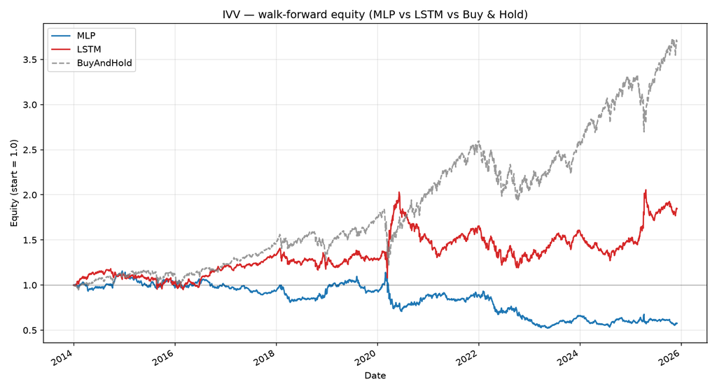

IVV — walk-forward equity curves (MLP vs LSTM vs Buy & Hold)

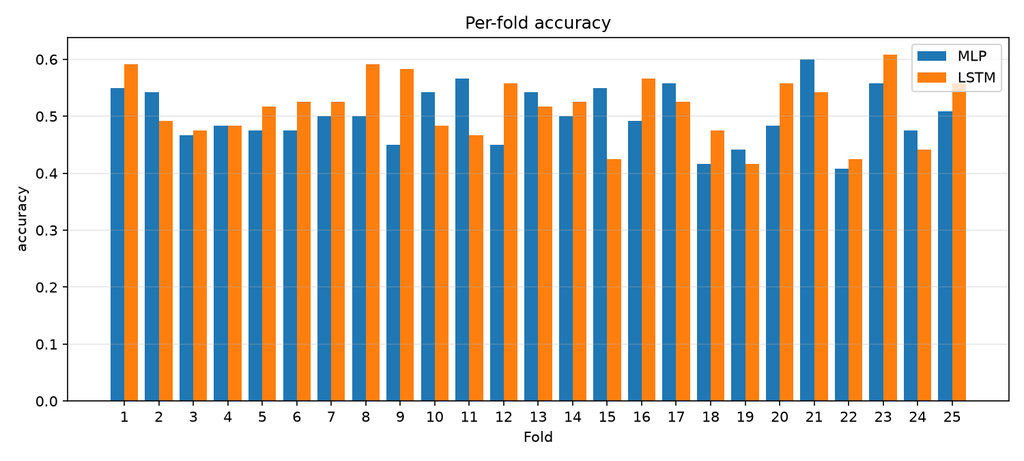

IVV — per-fold directional accuracy

IVV is the hardest benchmark to beat: a strong, persistent uptrend in which buy-and-hold compounds to about 3.7× with a Sharpe of 0.66. The LSTM is the better network here (Sharpe 0.30, about 1.85×), because its return target picks up the positive drift and it is long on about three days in four. The MLP is long only 61% of the time and loses money (Sharpe −0.26). On a trending index, any signal that spends a large share of days short gives up most of the drift.

### 5.5 Cross-ticker summary

```python
summary = pd.concat(
    {t: m[["total_return", "annual_return", "sharpe", "max_drawdown", "hit_rate"]]
     for t, m in metrics_all.items()},
    names=["ticker"],
).round(4)
summary
```

| ticker | model | total_return | annual_return | sharpe | max_drawdown | hit_rate |
| --- | --- | --- | --- | --- | --- | --- |
| EUFN | MLP | 4.0185 | 0.1451 | 0.6033 | -0.3631 | 0.5043 |
|  | LSTM | -0.0971 | -0.0085 | -0.0355 | -0.6042 | 0.4890 |
|  | BuyAndHold | 0.5182 | 0.0357 | 0.1483 | -0.5914 | 0.5148 |
| FEZ | MLP | 0.0147 | 0.0012 | 0.0059 | -0.5027 | 0.5013 |
|  | LSTM | -0.3562 | -0.0363 | -0.1742 | -0.5324 | 0.4913 |
|  | BuyAndHold | 0.5078 | 0.0351 | 0.1685 | -0.4416 | 0.5308 |
| IEUR | MLP | 0.1999 | 0.0242 | 0.1228 | -0.4406 | 0.4953 |
|  | LSTM | -0.1727 | -0.0246 | -0.1246 | -0.5479 | 0.4823 |
|  | BuyAndHold | 0.5046 | 0.0551 | 0.2796 | -0.3726 | 0.5336 |
| IVV | MLP | -0.4257 | -0.0455 | -0.2593 | -0.5479 | 0.5007 |
|  | LSTM | 0.8532 | 0.0532 | 0.3031 | -0.4134 | 0.5147 |
|  | BuyAndHold | 2.7042 | 0.1163 | 0.6631 | -0.3390 | 0.5458 |

Key takeaways from the table:

- **Only one of eight full-feature runs beats buy-and-hold**: the EUFN MLP (Sharpe 0.60 against 0.15), and that result rests on a handful of crash days.
- **Neither architecture dominates.** The MLP is ahead on the three European ETFs, the LSTM on IVV.
- **Hit rates cluster around 48–52%**: the daily signals are close to a coin flip, so where a strategy does well the result comes from the size of a few correctly called moves rather than from frequent correct calls.
- **Drawdowns are comparable to buy-and-hold or worse**, with the exception of the EUFN MLP.

### 5.6 Transaction costs

The results above assume free trading. The networks change position 25 to 107 times a year, so costs matter. `scripts/cost_sensitivity.py` re-scores every run with a one-way cost per unit traded (a long-to-short flip trades two units) and finds the cost at which each Sharpe ratio reaches zero.

```python
costs = pd.read_csv(RESULTS / "cost_sensitivity.csv")
costs[[
    "ticker", "model", "features", "flips_per_year",
    "sharpe_0bps", "sharpe_2bps", "sharpe_5bps",
    "breakeven_bps", "buy_and_hold_sharpe",
]].round(2)
```

|  | ticker | model | features | flips_per_year | sharpe_0bps | sharpe_2bps | sharpe_5bps | breakeven_bps | buy_and_hold_sharpe |
| --- | --- | --- | --- | --- | --- | --- | --- | --- | --- |
| 0 | IEUR | MLP | all | 92.53 | 0.12 | -0.07 | -0.34 | 1.29 | 0.28 |
| 1 | IEUR | LSTM | all | 41.61 | -0.12 | -0.21 | -0.33 | 0.00 | 0.28 |
| 2 | IEUR | MLP | top10 | 99.49 | 0.04 | -0.16 | -0.44 | 0.39 | 0.28 |
| 3 | IEUR | LSTM | top10 | 107.23 | 0.12 | -0.10 | -0.41 | 1.08 | 0.28 |
| 4 | FEZ | MLP | all | 96.43 | 0.01 | -0.18 | -0.44 | 0.06 | 0.17 |
| 5 | FEZ | LSTM | all | 33.77 | -0.17 | -0.24 | -0.33 | 0.00 | 0.17 |
| 6 | FEZ | MLP | top10 | 98.45 | -0.12 | -0.30 | -0.56 | 0.00 | 0.17 |
| 7 | FEZ | LSTM | top10 | 81.98 | 0.23 | 0.06 | -0.17 | 2.81 | 0.17 |
| 8 | EUFN | MLP | all | 90.64 | 0.60 | 0.43 | 0.19 | 7.47 | 0.15 |
| 9 | EUFN | LSTM | all | 52.33 | -0.04 | -0.12 | -0.25 | 0.00 | 0.15 |
| 10 | EUFN | MLP | top10 | 86.77 | 0.54 | 0.38 | 0.15 | 7.06 | 0.15 |
| 11 | EUFN | LSTM | top10 | 87.78 | 0.11 | -0.04 | -0.25 | 1.48 | 0.15 |
| 12 | IVV | MLP | all | 81.73 | -0.26 | -0.43 | -0.69 | 0.00 | 0.66 |
| 13 | IVV | LSTM | all | 25.20 | 0.30 | 0.24 | 0.15 | 10.27 | 0.66 |
| 14 | IVV | MLP | top10 | 84.76 | -0.14 | -0.32 | -0.59 | 0.00 | 0.66 |
| 15 | IVV | LSTM | top10 | 40.66 | 0.28 | 0.18 | 0.04 | 5.83 | 0.66 |

At about 5.5 bps per trade the EUFN MLP falls to buy-and-hold levels (5 bps for its top-10 version), and the FEZ LSTM on the top-10 features, the only other run that beats buy-and-hold before costs, falls below it at 1 bp.

## 6. Feature selection — top-10 vs full feature set

Sagaceta-Mejía et al. (2024) report that training the MLP on the **Selected(5)** subset (≈5% of the ~216 Pandas TA indicators) improved median 10-fold accuracy by ~2 pp over the full feature set on ECH / EWZ / IVV. To stress-test that claim on our 2010-2026 European ETFs (plus IVV as a US benchmark), we re-ran the walk-forward harness on a much smaller input space: the **top-10 features per ticker** taken directly from each ticker’s `reports/results/<TICKER>_feature_importance.csv` ranking that the preprocessing team produced upstream.

### 6.1 Selected features per ticker

```python
top10 = {
    t: pd.read_csv(RESULTS / f"{t}_feature_importance.csv")["feature"].head(10).tolist()
    for t in TICKERS
}
pd.DataFrame.from_dict(top10, orient="index").T
```

|  | EUFN | FEZ | IEUR | IVV |
| --- | --- | --- | --- | --- |
| 0 | SMCbp_14_50_20_5 | SMCtp_14_50_20_5 | SMCtp_14_50_20_5 | SMCtp_14_50_20_5 |
| 1 | SMCtp_14_50_20_5 | SMCbp_14_50_20_5 | SMCbi_14_50_20_5 | SMCbp_14_50_20_5 |
| 2 | CRSI_3_2_100 | SMCbi_14_50_20_5 | CRSI_3_2_100 | SMCbf_14_50_20_5 |
| 3 | SMCbi_14_50_20_5 | CRSI_3_2_100 | SMCbp_14_50_20_5 | Open |
| 4 | BBP_5_2.0_2.0 | SMCti_14_50_20_5 | BBP_5_2.0_2.0 | BBP_5_2.0_2.0 |
| 5 | SMCbf_14_50_20_5 | BBP_5_2.0_2.0 | DEC_1 | CFO_9 |
| 6 | SMCtf_14_50_20_5 | SMCbf_14_50_20_5 | THERMO_20_2_0.5 | BOP |
| 7 | THERMO_20_2_0.5 | BOP | INC_1 | SMCbi_14_50_20_5 |
| 8 | SMCti_14_50_20_5 | THERMO_20_2_0.5 | BOP | SMCti_14_50_20_5 |
| 9 | PVR | DEC_1 | SMCbf_14_50_20_5 | STOCHh_14_3_3 |

Across all four tickers, the top of the ranking is dominated by **Smart Money Concept** indicators (`SMCtp`, `SMCbi`, `SMCbp`, `SMCti`) and a handful of the same features called out in the paper’s Selected(5) — **BOP**, **BBP** and (on EUFN) **PVR** — confirming that the importance ranking surfaces broadly similar signals to the paper’s statistical-measure pipeline.

### 6.2 Reduced-set walk-forward results

```python
metrics_top10 = {
    t: pd.read_csv(RESULTS / f"{t}_walkforward_metrics_top10.csv", index_col=0)
    for t in TICKERS
}
pd.concat(
    {t: m[["total_return", "annual_return", "sharpe", "max_drawdown", "hit_rate"]]
     for t, m in metrics_top10.items()},
    names=["ticker"],
).round(4)
```

| ticker | model | total_return | annual_return | sharpe | max_drawdown | hit_rate |
| --- | --- | --- | --- | --- | --- | --- |
| EUFN | MLP | 3.3080 | 0.1305 | 0.5425 | -0.3501 | 0.5007 |
|  | LSTM | 0.3612 | 0.0262 | 0.1090 | -0.5867 | 0.4967 |
|  | BuyAndHold | 0.5182 | 0.0357 | 0.1483 | -0.5914 | 0.5148 |
| FEZ | MLP | -0.2639 | -0.0254 | -0.1219 | -0.4981 | 0.4993 |
|  | LSTM | 0.7321 | 0.0472 | 0.2266 | -0.4538 | 0.5123 |
|  | BuyAndHold | 0.5078 | 0.0351 | 0.1685 | -0.4416 | 0.5308 |
| IEUR | MLP | 0.0605 | 0.0077 | 0.0393 | -0.3842 | 0.4906 |
|  | LSTM | 0.1931 | 0.0234 | 0.1189 | -0.4091 | 0.5057 |
|  | BuyAndHold | 0.5046 | 0.0551 | 0.2796 | -0.3726 | 0.5336 |
| IVV | MLP | -0.2556 | -0.0245 | -0.1395 | -0.3841 | 0.4987 |
|  | LSTM | 0.7600 | 0.0486 | 0.2771 | -0.3566 | 0.5147 |
|  | BuyAndHold | 2.7042 | 0.1163 | 0.6631 | -0.3390 | 0.5458 |

Equity curves and per-fold accuracy under the reduced feature set:

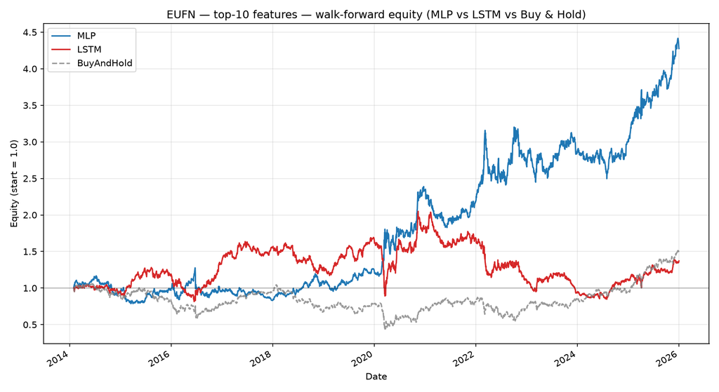

EUFN — top-10 features

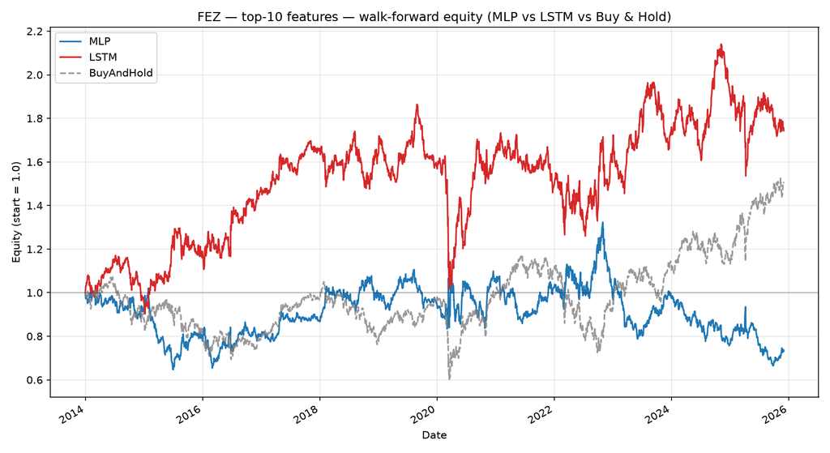

FEZ — top-10 features

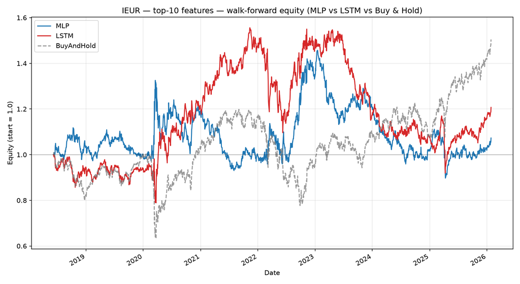

IEUR — top-10 features

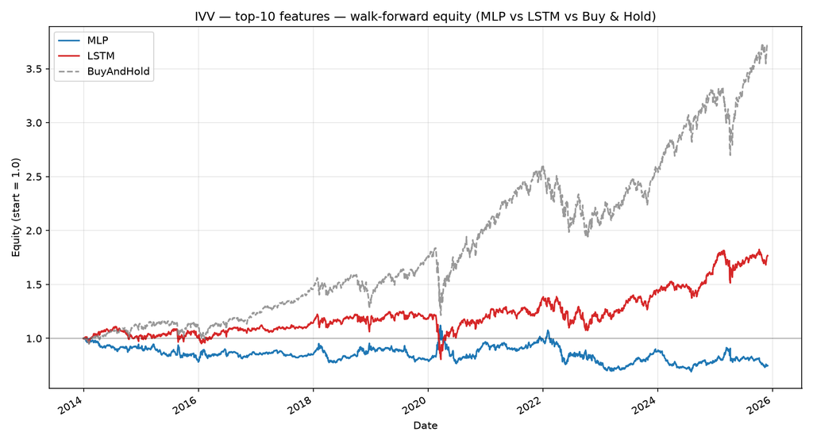

IVV — top-10 features

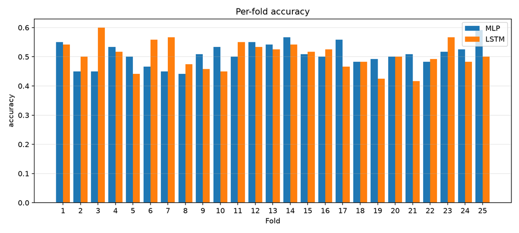

EUFN — per-fold accuracy (top-10)

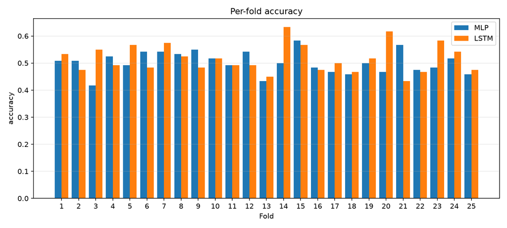

FEZ — per-fold accuracy (top-10)

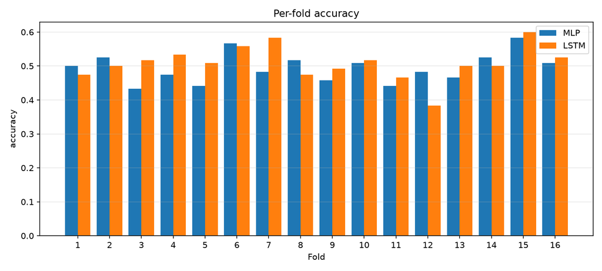

IEUR — per-fold accuracy (top-10)

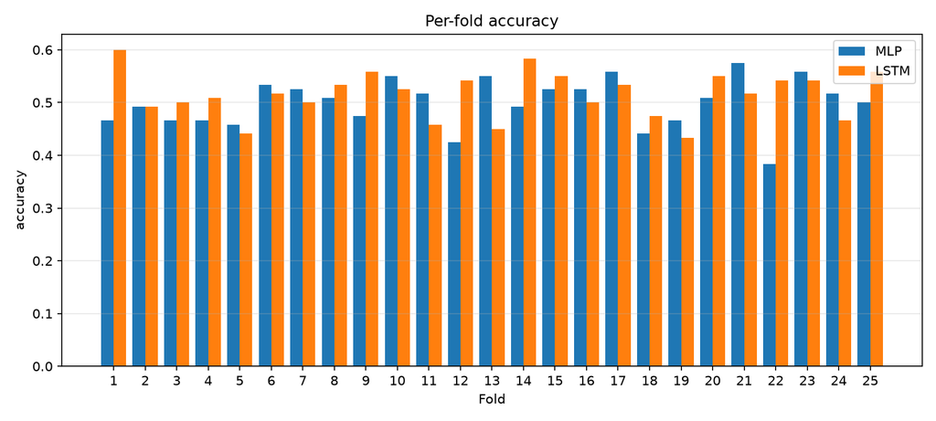

IVV — per-fold accuracy (top-10)

### 6.3 Head-to-head: full features vs top-10

```python
def _delta(full: pd.DataFrame, top: pd.DataFrame, model: str) -> dict:
    return {
        "Sharpe (full)":  full.loc[model, "sharpe"],
        "Sharpe (top10)": top.loc[model, "sharpe"],
        "Δ Sharpe":       top.loc[model, "sharpe"] - full.loc[model, "sharpe"],
        "Total ret (full)":  full.loc[model, "total_return"],
        "Total ret (top10)": top.loc[model, "total_return"],
    }

rows = []
for t in TICKERS:
    for model in ["MLP", "LSTM"]:
        row = {"ticker": t, "model": model,
               **_delta(metrics_all[t], metrics_top10[t], model)}
        rows.append(row)
pd.DataFrame(rows).set_index(["ticker", "model"]).round(3)
```

| ticker | model | Sharpe (full) | Sharpe (top10) | Δ Sharpe | Total ret (full) | Total ret (top10) |
| --- | --- | --- | --- | --- | --- | --- |
| EUFN | MLP | 0.603 | 0.543 | -0.061 | 4.019 | 3.308 |
|  | LSTM | -0.035 | 0.109 | 0.144 | -0.097 | 0.361 |
| FEZ | MLP | 0.006 | -0.122 | -0.128 | 0.015 | -0.264 |
|  | LSTM | -0.174 | 0.227 | 0.401 | -0.356 | 0.732 |
| IEUR | MLP | 0.123 | 0.039 | -0.084 | 0.200 | 0.061 |
|  | LSTM | -0.125 | 0.119 | 0.244 | -0.173 | 0.193 |
| IVV | MLP | -0.259 | -0.139 | 0.120 | -0.426 | -0.256 |
|  | LSTM | 0.303 | 0.277 | -0.026 | 0.853 | 0.760 |

### 6.4 Interpretation

Pruning to ten features does not have one consistent effect:

- **MLP:** the full feature set is better on three of four tickers (EUFN 0.60 → 0.54, FEZ 0.01 → −0.12, IEUR 0.12 → 0.04); only IVV improves (−0.26 → −0.14), and it stays negative.
- **LSTM:** the top-10 set is better on three of four tickers (EUFN −0.04 → 0.11, FEZ −0.17 → 0.23, IEUR −0.12 → 0.12) and roughly neutral on IVV (0.30 → 0.28).

So the paper’s finding that a small feature subset helps the MLP does not carry over to our setup, while the LSTM does benefit from fewer inputs. A few reasons the results differ from the paper:

1. **Different validation protocol.** The paper uses **10-fold shuffled `StratifiedKFold`** (an i.i.d. assumption), which lets the MLP see future-dated rows during training. We use a strict **expanding-window walk-forward**, so every test row is genuinely out-of-sample. Shuffled CV scores on price series are well-known to be optimistically biased, and feature subsets that look good under shuffled CV often lose their edge under temporal validation.
2. **Different feature pool.** The paper has 216 Pandas TA columns; our pipeline produces about 250 (a different Pandas TA version, plus the SMC family that dominates the importance ranking). The top of the importance list is therefore a different set of signals.
3. **Model capacity.** With about 250 features in each of 20 time steps and a few thousand training rows, the full-feature LSTM has far more inputs than the data can support, so cutting to ten features acts as regularisation. The MLP sees a single day at a time and is less exposed to this.
4. **Different dataset window.** The paper deliberately ends in 2020-01 to exclude the COVID period; our backtest covers 2014-2026, including the 2020 shock, the 2022 rate cycle and the 2023-25 recovery.

Given how close most of these Sharpe ratios are to zero, and that each model is trained with a single seed, the differences between feature sets are small relative to the noise. A middle-ground experiment (for example the top 30 to 60 features, retrained over several seeds) is the natural next step.

## 7. Reproducing the results

```bash
# from the project root — full feature baseline
PYTHONPATH=src python scripts/run_modeling.py
# or simply
make modeling

# top-10 features per ticker (suffix keeps the baseline files intact)
PYTHONPATH=src python scripts/run_modeling.py \
    --top-k-features 10 --feature-suffix _top10

# Sharpe ratios net of transaction costs for every saved run
PYTHONPATH=src python scripts/cost_sensitivity.py
```

Useful CLI flags:

```bash
# Smoke test — 3 folds only
PYTHONPATH=src python scripts/run_modeling.py --max-folds 3

# Train a single ticker with custom epochs / look-back
PYTHONPATH=src python scripts/run_modeling.py \
    --tickers FEZ --mlp-epochs 50 --lstm-epochs 30 --lstm-seq-len 30
```

Each run regenerates (with optional `<suffix>` from `--feature-suffix`):

- `reports/figures/equity_<TICKER><suffix>.png`
- `reports/figures/fold_accuracy_<TICKER><suffix>.png`
- `reports/results/<TICKER>_walkforward_metrics<suffix>.csv`
- `reports/results/<TICKER>_<model>_folds<suffix>.csv`
- `reports/results/<TICKER>_<model>_predictions<suffix>.csv`
- `reports/results/<TICKER>_equity_curves<suffix>.csv`

## 8. Limitations & next steps

- **Simple cost model.** Trading costs are a flat charge per unit traded (section 5.6). Borrowing costs for the short side, the bid/ask spread at the open and market impact are not modelled.
- **Same-day training label for the MLP.** Following the paper, the MLP learns Γ(t), which is already known by the close of day *t*, while its signal trades the following day’s return. Training on a next-day target would match what the model learns to what it trades.
- **One seed per model.** Each network is trained with a single fixed seed, so the spread of these Sharpe ratios across training runs is unknown.
- **Position sizing is binary.** A confidence-weighted sizing scheme (scaling by predicted probability or predicted return magnitude) would likely smooth the equity curves.
- **No hyper-parameter search.** Architecture sizes, epoch counts, dropout and sequence length are fixed at sensible defaults. A walk-forward-aware tuning loop (e.g. nested validation on the training block) would be the natural next step.

## 9. References

Sagaceta-Mejía, A. R., Sánchez-Gutiérrez, M. E., & Fresán-Figueroa, J. A. (2024). An intelligent approach for predicting stock market movements in emerging markets using optimized technical indicators and neural networks. *Economics*, 18, 20220073. https://doi.org/10.1515/econ-2022-0073